# StatComp Project 2: Scottish weather

Peter Ly (s1325633, peter-lyy)

# 1 Weather data

```r
# Modify this code chunk to add extra packages etc if needed,
# and to load the weather data.

# Load function definitions
source("my_functions.R")

# Load common packages
suppressPackageStartupMessages(library(tidyverse))
suppressPackageStartupMessages(library(StatCompLab))
theme_set(theme_bw())
```

This report will be analysing data from the Global Historical Climatology Network at https://www.ncdc.noaa.gov/data-access/land-based-station-data/land-based-datasets/global-historical-climatology-network-ghcn. I will be specifically looking at data from eight weather stations in Scotland. The data includes the minimum temperature, `TMIN`, maximum temperature, `TMAX`, and precipitation, `PRCP`, recorded every day (when possible to) between 1960 - 2018. Below you will find the eight Scottish weather stations and their location in latitude, longitude and elevation(meters) above sea level, along with their respective IDs:

```r
station_info <- readRDS(file = "data/station_info.rds")

knitr::kable(station_info)
```

| ID | Name | Latitude | Longitude | Elevation |
| --- | --- | --- | --- | --- |
| UKE00105874 | BRAEMAR | 57.0058 | -3.3967 | 339 |
| UKE00105875 | BALMORAL | 57.0367 | -3.2200 | 283 |
| UKE00105884 | ARDTALNAIG | 56.5289 | -4.1108 | 130 |
| UKE00105885 | FASKALLY | 56.7181 | -3.7689 | 94 |
| UKE00105886 | LEUCHARS | 56.3767 | -2.8617 | 10 |
| UKE00105887 | PENICUIK | 55.8239 | -3.2258 | 185 |
| UKE00105888 | EDINBURGH: ROYAL BOTANIC GARDE | 55.9667 | -3.2100 | 26 |
| UKE00105930 | BENMORE: YOUNGER BOTANIC GARDE | 56.0281 | -4.9858 | 12 |

# 2 Climate trends

## 2.1 Monthly Trends

To assess whether there is a long-term temporal trend in the minimum temperature , `TMIN`, at each station for each month, I will first display whether a trend even exists in January for all stations. Below you will find a graph of the observed average TMIN for January against years, from 1960 to 2018. The red line represents an estimated linear model given by: $\overline{TMIN}_{m(t)} = \beta(Year) + c$ and the grey band is 95% predicition interval. $\beta$ represents the long-term temporal trend and $c$ represents the estimated average `TMIN` for that month, $\overline{TMIN}_{m(t)}$ at year 0. Therefore, for predicting $\overline{TMIN}_{m(t)}$ pre-1960 and post 2018 will be interpolating the data and should be done with caution.

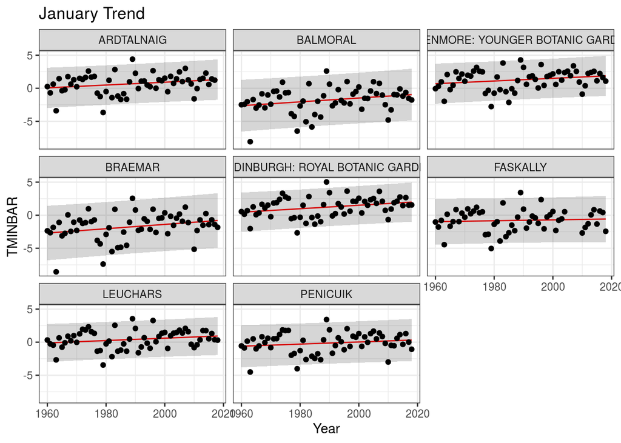

```r
seasonal_TMIN <- readRDS(file = "data/seasonal_TMIN.rds")
Jan_pred <- readRDS(file = "data/Jan_pred.rds")

ggplot(Jan_pred, mapping = aes(Year, pred.fit)) +
  geom_line(Jan_pred, mapping = aes(Year, pred.fit), colour = "Red") +
  geom_ribbon(mapping = aes(ymin = pred.lwr, ymax = pred.upr), alpha = 0.2) +
  geom_point(data = seasonal_TMIN %>%
               filter(Month == 1), aes(Year, TMINBAR)) +
  ylab("TMINBAR") +
  facet_wrap(~ Name) +
  ggtitle("January Trend")
```

The graph above shows there is a small positive trend the January average `TMIN` value against year. Therefore, it would be worthwhile to apply a linear model to all months and evaluate the year coefficient to see the long-term temporal trend. The graphs below shows each estimated long-term temporal trend per year for each month at all 8 stations, with 95% confidence intervals:

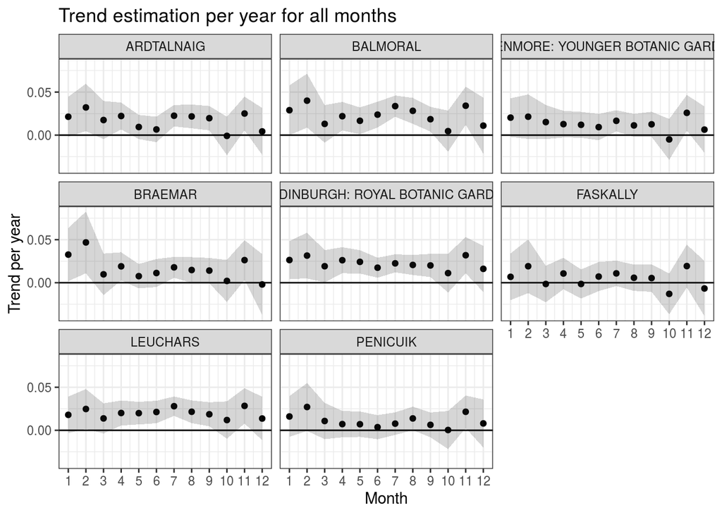

```r
trend_est <- readRDS(file = "data/trend_est.rds")
trend_est %>%
  group_by(ID, Name, Month) %>%
  ggplot(aes(Month, trend)) +
  geom_point() +
  geom_ribbon(aes(ymin = lwr, ymax = upr), alpha = 0.2)+
  geom_hline(yintercept=0) +
  scale_x_continuous(breaks = seq(0,12,1)) +
  ylab("Trend per year") +
  facet_wrap(~ Name) +
  ggtitle("Trend estimation per year for all months")
```

Since the estimated trend appears to be very small per year, I have scaled the estimated trend to evaluate the change per century. The graph below shows the results:

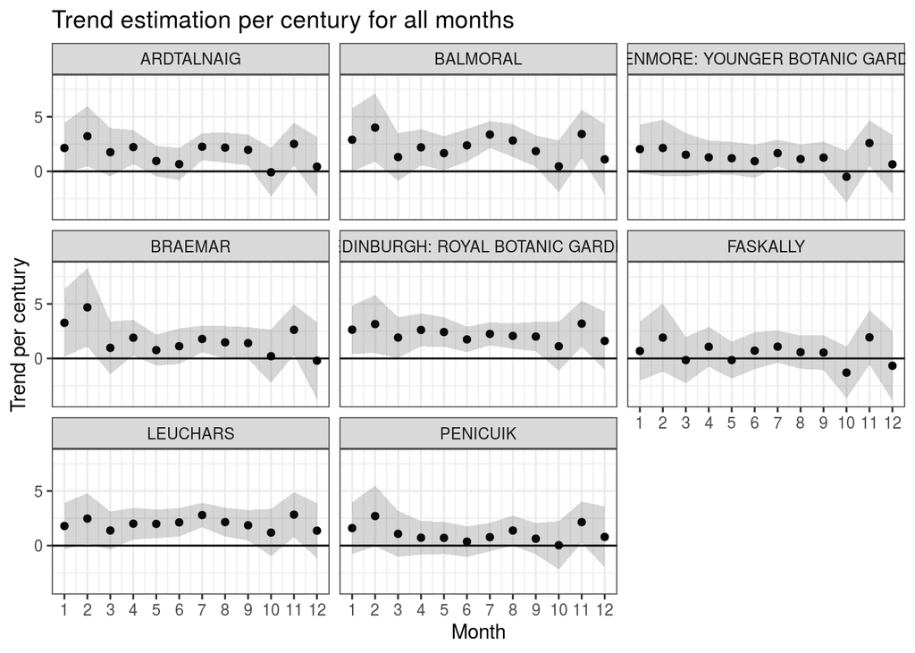

```r
trend_est <- readRDS(file = "data/trend_est.rds")

trend_est_scaled <- trend_est %>%
  mutate(trend_century = trend*100,
         lwr_century = lwr*100,
         upr_century = upr*100)

trend_est_scaled %>%
  group_by(ID, Name, Month) %>%
  ggplot(aes(Month, trend_century)) +
  geom_point() +
  geom_ribbon(aes(ymin = lwr_century, ymax = upr_century), alpha = 0.2)+
  geom_hline(yintercept=0) +
  scale_x_continuous(breaks = seq(0,12,1)) +
  ylab("Trend per century") +
  facet_wrap(~ Name) +
  ggtitle("Trend estimation per century for all months")
```

In the graph above, I have plotted the trend over a century for each month, and each graph represents each of the 8 stations. The grey band represents the 95% confidence interval for the trend.  
The way in which we can interpret this graph is that the “Trend per century” represents an change in average minimum temperature, `TMIN`, for that month over a century. For example, the weather station at Braemar is recording an increase in average minimum temperature in February at approximately 5 degrees celsius per century.  
What we observe is that there is generally a small positive trend over years for the average monthly `TMIN` value. This means as time goes on we will see a small increase in average monthly `TMIN` value. However the trend is not consistent for all months across all stations. The bar chart below will provide a visual representation of the stability of the trend within the same month across stations.

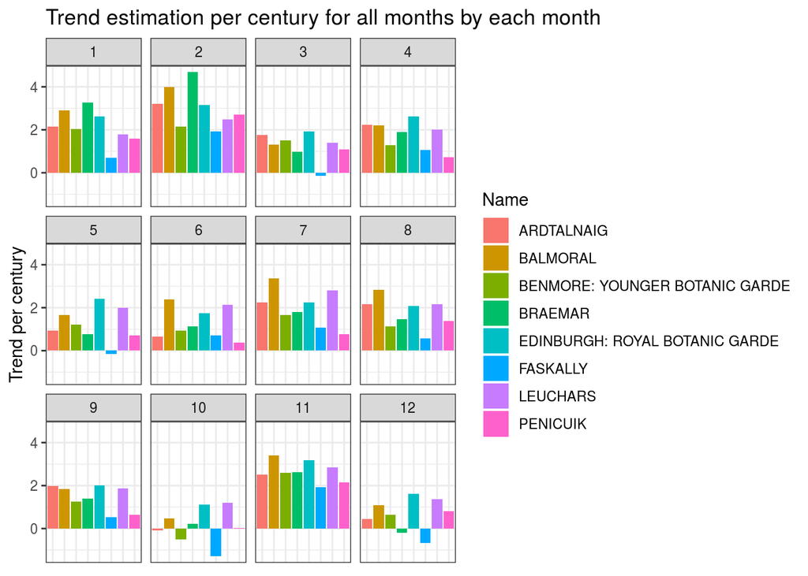

```r
trend_est <- readRDS(file = "data/trend_est.rds")

trend_est_scaled <- trend_est %>%
  mutate(trend_century = trend*100,
         lwr_century = lwr*100,
         upr_century = upr*100)

trend_est_scaled %>%
  ggplot(aes(Name, trend_century, fill = Name)) +
  geom_bar(stat = "identity") +
  theme(axis.title.x=element_blank(),
        axis.text.x=element_blank(),
        axis.ticks.x=element_blank()) +
  ylab("Trend per century") +
  facet_wrap(~ Month) +
  ggtitle("Trend estimation per century for all months by each month")
```

### 2.1.1 November Trends

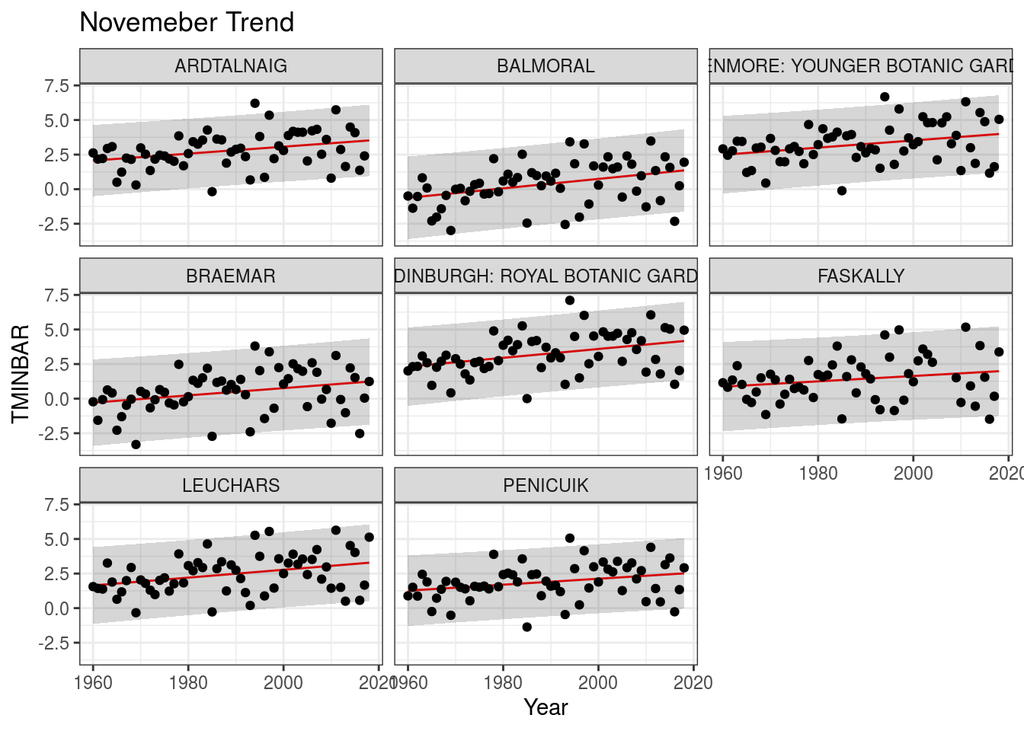

```r
seasonal_TMIN <- readRDS(file = "data/seasonal_TMIN.rds")
Nov_pred <- readRDS(file = "data/Nov_pred.rds")
ggplot(Nov_pred, mapping = aes(Year, pred.fit)) +
  geom_line(Nov_pred, mapping = aes(Year, pred.fit), colour = "Red") +
  geom_ribbon(mapping = aes(ymin = pred.lwr, ymax = pred.upr), alpha = 0.2) +
  geom_point(data = seasonal_TMIN %>%
               filter(Month == 11), aes(Year, TMINBAR)) +
  ylab("TMINBAR") +
  facet_wrap(~ Name) +
  ggtitle("Novemeber Trend")
```

To further illustrate the differences in trends across months, the graph above shows us the average `TMIN` value against year for the month of November. We can see that there is a positive trend over time for all stations. This would indicate to us that in November, the average `TMIN` is increasing over time. Therefore, we see higher average minimum temperatures in November which means on average it is not as cold as it has been in previous years.

### 2.1.2 October Trends

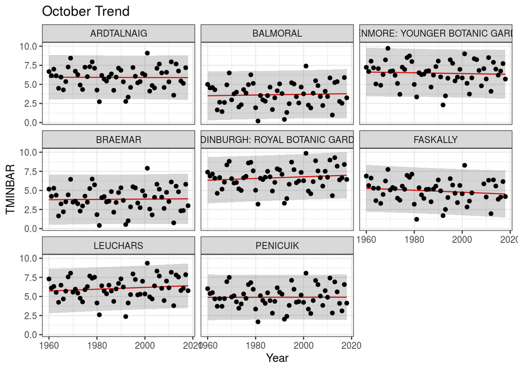

```r
seasonal_TMIN <- readRDS(file = "data/seasonal_TMIN.rds")
Oct_pred <- readRDS(file = "data/Oct_pred.rds")
ggplot(Oct_pred, mapping = aes(Year, pred.fit)) +
  geom_line(Oct_pred, mapping = aes(Year, pred.fit), colour = "Red") +
  geom_ribbon(mapping = aes(ymin = pred.lwr, ymax = pred.upr), alpha = 0.2) +
  geom_point(data = seasonal_TMIN %>%
               filter(Month == 10), aes(Year, TMINBAR)) +
  ylab("TMINBAR") +
  facet_wrap(~ Name) +
  ggtitle("October Trend")
```

In contrast, October seems to have a lower, and in some cases, negative trend over years. At the stations Benmore, Faskally and Ardtalnaig there is a slightly negative trend over years. However, the estimated trend has some variance, so it would be reasonable to assume that there is no trend rather than a small negative trend.

### 2.1.3 December Trends

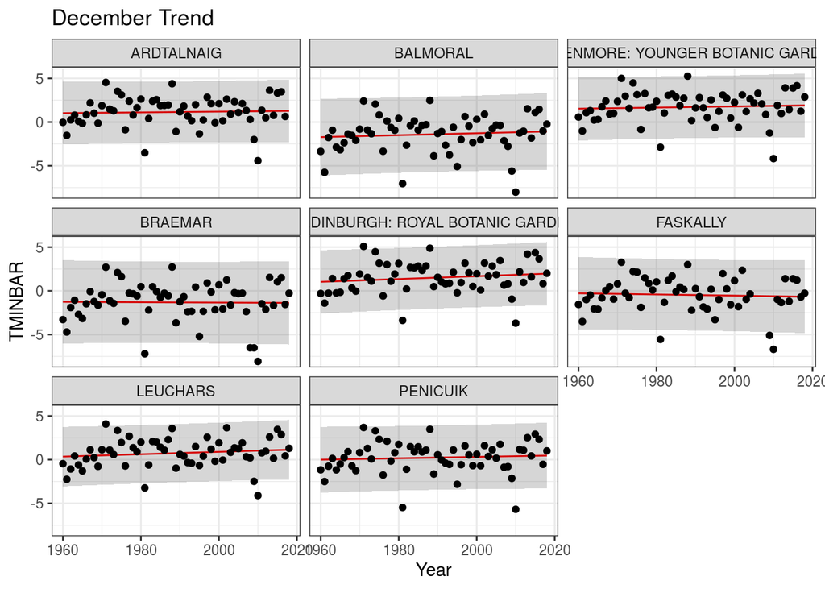

```r
seasonal_TMIN <- readRDS(file = "data/seasonal_TMIN.rds")
Dec_pred <- readRDS(file = "data/Dec_pred.rds")
ggplot(Dec_pred, mapping = aes(Year, pred.fit)) +
  geom_line(Dec_pred, mapping = aes(Year, pred.fit), colour = "Red") +
  geom_ribbon(mapping = aes(ymin = pred.lwr, ymax = pred.upr), alpha = 0.2) +
  geom_point(data = seasonal_TMIN %>%
               filter(Month == 12), aes(Year, TMINBAR)) +
  ylab("TMINBAR") +
  facet_wrap(~ Name) +
  ggtitle("December Trend")
```

## 2.2 Seasonally varying variability

To assess whether the temperature variability is the same for each month of the year I will be looking at the Balmoral station daily `TMIN` residuals from the month averages. I define the residuals as $R_t = T_t - \overline{T}_{m(t)}$, where $T_t$ is `TMIN` at time $t$, and $\overline{T}_{m(t)}$ is the average `TMIN` value in the month of time $t$. I will be testing whether the daily `TMIN` residuals within a month are larger than the overall residual variance.
Our hypotheses are:
$$H_0: \text {The residual variance is the same for all months of the year} \\
H_1: \text {The residual variance for January is higher than the overall variance}$$
and similarly for all other month.
First, I will define the observed test statistic as
$$\text{Test statistic} = var(R_{m(t)}) - var(R_t)$$
which is to say, the difference in variance in a given month of time $t$ and the variance of the whole set of residuals. Since this is a one-sided test to see if the variance of the residual from one month is larger than the variance of the set of residuals. I have formulated the test statistic to see the positive difference.
The observed test statistics are given in the table below:

```r
T_Month <- readRDS(file = "data/T_Month.rds")
knitr::kable(T_Month)
```

| Month | T_Month | H0 | T_stat |
| --- | --- | --- | --- |
| 1 | 16.235135 | 11.99151 | 4.2436238 |
| 2 | 15.618038 | 11.99151 | 3.6265266 |
| 3 | 11.645986 | 11.99151 | -0.3455250 |
| 4 | 10.334631 | 11.99151 | -1.6568802 |
| 5 | 9.904222 | 11.99151 | -2.0872892 |
| 6 | 8.562389 | 11.99151 | -3.4291220 |
| 7 | 7.708484 | 11.99151 | -4.2830266 |
| 8 | 9.565547 | 11.99151 | -2.4259643 |
| 9 | 11.405000 | 11.99151 | -0.5865109 |
| 10 | 12.160173 | 11.99151 | 0.1686622 |
| 11 | 14.392107 | 11.99151 | 2.4005962 |
| 12 | 16.602199 | 11.99151 | 4.6106877 |

Since there is a large number of possible permutations, beyond the capabilities of my workstation, I will be performing a randomisation test to see if there is sufficient evidence to reject the null hypothesis.  
The upper bound of the standard deviation of the p-value is given by $1/\sqrt{4M}$. As a result, I have performed $2500$ permutations of the data to calculate the p-value to a standard deviation of 0.01.  
Below you will find a table of the calculated p-values for each month at the Balmoral station:

```r
pvalues <- readRDS(file = "data/pvalues.rds")
knitr::kable(pvalues)
```

| Month | pvalue |
| --- | --- |
| 1 | 0.0000 |
| 2 | 0.0000 |
| 3 | 0.7880 |
| 4 | 1.0000 |
| 5 | 1.0000 |
| 6 | 1.0000 |
| 7 | 1.0000 |
| 8 | 1.0000 |
| 9 | 0.9164 |
| 10 | 0.3464 |
| 11 | 0.0000 |
| 12 | 0.0000 |

# 3 Spatial weather prediction

## 3.1 Estimation

The weather station I have chosen to estimate a linear model for is Edinburgh: Royal Botanic Garde. The linear model will predict the daily maximum temperature, `TMAX`, at the Edinburgh weather station using the 7 other stations and Year as covariates. I will estimate a linear model for each month of the year.  
Below you will find a table of the coefficients of all covariates and the intercept of the estimated linear model:

```r
Edin_model <- readRDS(file = "data/Edin_model.rds")
knitr::kable(Edin_model)
```

| ID | Name | Month | (Intercept) | UKE00105874 | UKE00105875 | UKE00105884 | UKE00105885 | UKE00105886 | UKE00105887 | UKE00105930 | Year |
| --- | --- | --- | --- | --- | --- | --- | --- | --- | --- | --- | --- |
| UKE00105888 | EDINBURGH: ROYAL BOTANIC GARDE | 1 | 5.167786 | -0.0510624 | 0.0264702 | 0.0782827 | -0.0535950 | 0.3367438 | 0.4720412 | 0.2201165 | -0.0022888 |
| UKE00105888 | EDINBURGH: ROYAL BOTANIC GARDE | 2 | 0.415828 | -0.1114989 | 0.1124204 | 0.0303980 | -0.0778315 | 0.3945294 | 0.5488249 | 0.1143426 | 0.0001623 |
| UKE00105888 | EDINBURGH: ROYAL BOTANIC GARDE | 3 | 4.748618 | -0.0243217 | 0.0194527 | -0.0188910 | -0.1078024 | 0.5338197 | 0.4713329 | 0.1075609 | -0.0020471 |
| UKE00105888 | EDINBURGH: ROYAL BOTANIC GARDE | 4 | 2.530060 | -0.0114008 | -0.0160266 | -0.0282355 | -0.0642628 | 0.5206657 | 0.5232977 | 0.0385885 | -0.0008788 |
| UKE00105888 | EDINBURGH: ROYAL BOTANIC GARDE | 5 | 12.559714 | -0.0136021 | -0.0409086 | -0.0196575 | -0.0297159 | 0.4617616 | 0.5841268 | -0.0132593 | -0.0056310 |
| UKE00105888 | EDINBURGH: ROYAL BOTANIC GARDE | 6 | -3.910384 | -0.0277568 | -0.0724955 | -0.0415149 | 0.0763364 | 0.4443402 | 0.5463749 | 0.0058304 | 0.0026302 |
| UKE00105888 | EDINBURGH: ROYAL BOTANIC GARDE | 7 | -7.070721 | -0.0521135 | -0.0702933 | -0.0118494 | 0.1080776 | 0.4249245 | 0.5438046 | -0.0382479 | 0.0044533 |
| UKE00105888 | EDINBURGH: ROYAL BOTANIC GARDE | 8 | -7.845750 | -0.0067258 | -0.0527463 | -0.0156752 | -0.0042984 | 0.4109186 | 0.5468530 | 0.0146939 | 0.0050568 |
| UKE00105888 | EDINBURGH: ROYAL BOTANIC GARDE | 9 | 1.428979 | -0.0730696 | 0.0659322 | 0.0031785 | -0.0754671 | 0.4354722 | 0.5028338 | 0.0955135 | -0.0001107 |
| UKE00105888 | EDINBURGH: ROYAL BOTANIC GARDE | 10 | -4.650025 | -0.1325062 | 0.1047731 | 0.0566988 | -0.0922954 | 0.4722369 | 0.4693005 | 0.1511667 | 0.0024834 |
| UKE00105888 | EDINBURGH: ROYAL BOTANIC GARDE | 11 | -2.160441 | -0.0508737 | 0.0848657 | 0.0442595 | -0.0549109 | 0.3758637 | 0.4555294 | 0.1739467 | 0.0013709 |
| UKE00105888 | EDINBURGH: ROYAL BOTANIC GARDE | 12 | 2.513994 | 0.0207425 | -0.0171255 | 0.0242396 | -0.0293784 | 0.3980769 | 0.4042687 | 0.2374048 | -0.0010620 |

To illustrate the interesting characteristics of the models, I have constructed a graph below of the results plotted against the individual months:

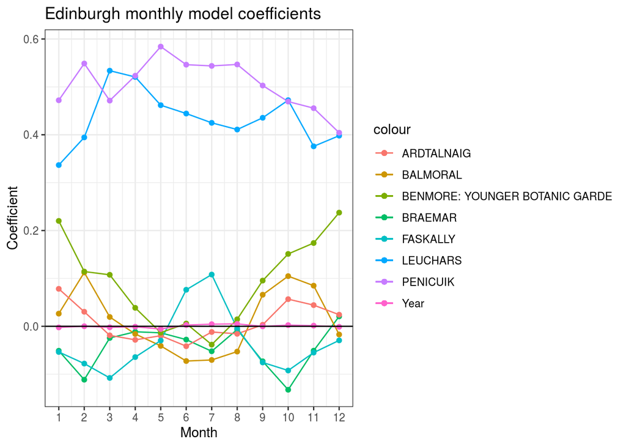

```r
Edin_model <- readRDS(file = "data/Edin_model.rds")
ggplot(Edin_model) +
  geom_line(aes(Month, UKE00105874, colour = "BRAEMAR")) +
  geom_line(aes(Month, UKE00105875, colour = "BALMORAL")) +
  geom_line(aes(Month, UKE00105884, colour = "ARDTALNAIG")) +
  geom_line(aes(Month, UKE00105885, colour = "FASKALLY")) +
  geom_line(aes(Month, UKE00105886, colour = "LEUCHARS")) +
  geom_line(aes(Month, UKE00105887, colour = "PENICUIK")) +
  geom_line(aes(Month, UKE00105930, colour = "BENMORE: YOUNGER BOTANIC GARDE")) +
  geom_line(aes(Month, Year, colour = "Year")) +
  geom_point(aes(Month, UKE00105874, colour = "BRAEMAR")) +
  geom_point(aes(Month, UKE00105875, colour = "BALMORAL")) +
  geom_point(aes(Month, UKE00105884, colour = "ARDTALNAIG")) +
  geom_point(aes(Month, UKE00105885, colour = "FASKALLY")) +
  geom_point(aes(Month, UKE00105886, colour = "LEUCHARS")) +
  geom_point(aes(Month, UKE00105887, colour = "PENICUIK")) +
  geom_point(aes(Month, UKE00105930, colour = "BENMORE: YOUNGER BOTANIC GARDE")) +
  geom_point(aes(Month, Year, colour = "Year")) +
  geom_hline(yintercept=0) +
  scale_x_continuous(breaks = seq(0,12,1)) +
  ylab("Coefficient") +
  ggtitle("Edinburgh monthly model coefficients")
```

There are a few intriguing characteristics we can draw on from the estimated linear models. Firstly, the coefficients for the year covariates are very small and almost negligible. This means that year has little to no effect on the estimating the daily `TMAX` at the Edinburgh weather station compared to the other covariates.  
To assess the coefficient at each station on the daily `TMAX` prediction for the Edinburgh weather station I have included an image of the location of all 8 weather stations, using GeoJSON. The light blue marker is the Edinburgh weather station and the red lines are the distances to the other stations.

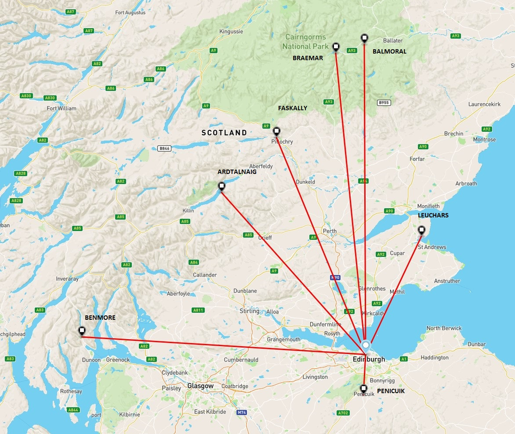

```r
knitr::include_graphics("images/weather stations.jpg")
```

There are only two stations have a consistently positive relationship with the Edinburgh weather station in all months, those are: Leuchars (UKE00105886) and Penicuik (UKE00105887). The reason why we see the positive coefficients for Leuchars in our estimated model is because of the short distance between the two stations and the similarity in elevation from sea level. The distance between the two stations is approximately 50km, which makes it the second closest station. Furthermore, difference in elevation is approximately 16m making it also the second closest in elevation. As for Penicuik, it is the closest station to Edinburgh at approximately 16 km. This would explain the positive relationship between the two weather stations and their recorded `TMAX` temperature, despite having an elevation difference of approximately 160m.  
On the other hand, the station Braemar (UKE00105874) has a small negative or negible relationship with the Edinburgh weather station. We can attribute this to the large difference in elevation, at 313m. The distance between the two is approximately 116 km, and which is similar to the distance to Benmore, and we will see later an interesting relationship between Edinburgh and Benmore stations. Therefore we can attribute the lack of a positive relationship due to the difference in elevation.  
When assessing the coefficient for the Benmore: Younger Botanic Garde(UKE00105930) weather station we see it has a positive relationship with the Edinburgh station during the autumn and winter months (October-March) but little to no relationship during the rest of the seasons. This is due to the geographic similarities between the two stations. There is approximately 14m in elevation difference but the distance between the two stations is approximately 110km. Furthermore, both weather stations are situated at opposite coasts in Scotland. This helps explain the unusual relationship and the coefficient. What we see is that both stations experience similar daily `TMAX` during the autumn and winter months.  
Finally, the Faskally (UKE00105885) weather station has a interesting geographic location when comparing to the Edinburgh weather station. With the elevation difference being 68m and the distance being 90km, we might expect a small positive coefficient. However, this is not the case, since all coefficients for that station is below 0.1 in all months expect July. The cause of this may be the geographic location of the Faskally. This weather station is located on a slight elevation and surround by larger hills and mountains. The valley like positioning of this station has had an influence on the `TMAX` recorded.  
To demonstrate how effective the linear models for each month is at predicting the daily `TMAX`, I have plotted the observed value at the Edinburgh weather station against the predicted value from the linear model. Below we see the scatter plot for all months:

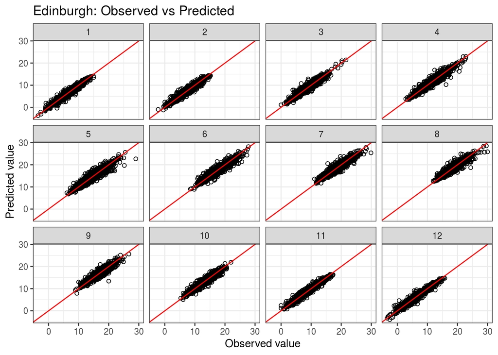

```r
Edin_pred <- readRDS(file = "data/Edin_pred.rds")

ggplot(Edin_pred) +
  geom_point(shape=1, aes(True_value, pred)) +
  geom_abline(intercept = 0, slope = 1, col = "red") +
  xlab("Observed value") +
  ylab("Predicted value") +
  facet_wrap(~ Month) +
  ggtitle("Edinburgh: Observed vs Predicted")
```

The red line represents when the observed value is equal to the predicted value. Therefore we can informally assess how good the estimated linear model is for predicting the observed value visually. The closer the points are to the red line the more accurate the prediction is and therefore a better the linear model. The residuals could be calculated by finding the distance every point is from the red line. Predicted values which are less than the observed value fall below the red line, and predicted values which are greater than the observed values are above the red line.  
I would like to bring to your attention two models, firstly the November model:

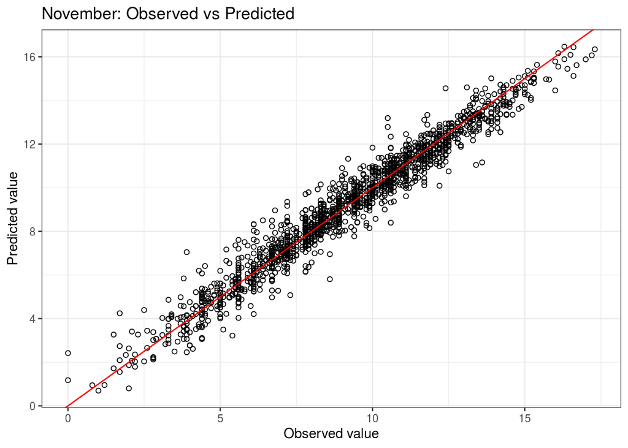

```r
Edin_Nov_pred <- readRDS(file = "data/Edin_Nov_pred.rds")

ggplot(Edin_Nov_pred) +
  geom_point(shape=1, aes(True_value, pred)) +
  geom_abline(intercept = 0, slope = 1, col = "red") +
  ggtitle("November: Observed vs Predicted") +
  xlab("Observed value") +
  ylab("Predicted value")
```

A feature this scatter plot are that the points on the graph are generally close to the red line and that would indicate the estimated linear model is fairly accurate at predicting the true daily `TMAX` values. There are very few points which deviate from the red line.  
The second model is the May Model:

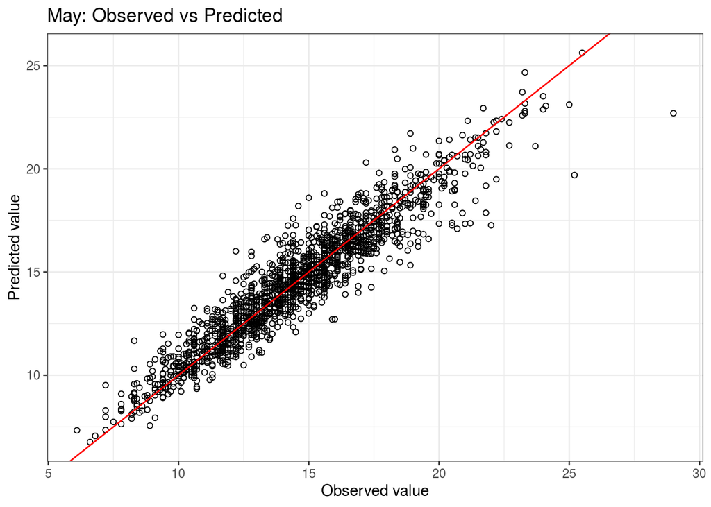

```r
Edin_May_pred <- readRDS(file = "data/Edin_May_pred.rds")

ggplot(Edin_May_pred) +
  geom_point(shape=1, aes(True_value, pred)) +
  geom_abline(intercept = 0, slope = 1, col = "red") +
  ggtitle("May: Observed vs Predicted") +
  xlab("Observed value") +
  ylab("Predicted value")
```

The features for the May scatter plot are the points seems to have a larger cluster width around the red line. Also there are some points that the under predicted by up to 5 degrees.  
Informally, we can see that the November model is better at predicting the true value than the May model for the Edinburgh weather station. In the next section, I will be formally assessing this in the next section using the Absolute Error score and Dawid-Sebastiani score.

## 3.2 Assessment

To assess the predictive power of each of the 12 models, I will be estimating the absolute error score and the Dawid-Sebstiani scores for each of the models. To estimate these scores I will be using a 10-fold cross-validation. This means I will be randomingly splitting the data into 10 subsets; using 9 subsets to train the model and the remaining subset will be used to validate the model. The model will predict `TMAX` values for the validating data. From the predictions I will estimate the Absolute Error scores and Dawid-Sebastiani scores. Repeating this procedure 10 times will allow me to perform a 10-fold randomised cross-validation. Therefore I will be using all 10 subsets of the data as validating data once, for each of the 12 models. By taking the average of the scores, we will have estimated the Absolute Error score and Dawid-Sebastiani and its standard deviation.  
It must be noted that in an ideal scenario, the size of the data for each month would be divisible by 10, so that the sizes of all 10 subsets could be the same. However, this is not the case and resulted in some subsets being one observation larger than others.  
Below you will find a table of my results from the 10-fold cross-validation estimation of the Absolute Error and Dawid-Sebastiani scores:

```r
score_summary <- readRDS(file = "data/score_summary.rds")
knitr::kable(score_summary)
```

| Month | mean_ae | sd_ae | mean_ds | sd_ds |
| --- | --- | --- | --- | --- |
| 1 | 0.5181940 | 0.0110458 | 0.2806736 | 0.0523727 |
| 2 | 0.5538829 | 0.0125432 | 0.4161371 | 0.0519623 |
| 3 | 0.6364767 | 0.0101371 | 0.6545114 | 0.0439229 |
| 4 | 0.6819980 | 0.0212737 | 0.8457265 | 0.0685682 |
| 5 | 0.7829038 | 0.0147842 | 1.1026196 | 0.0342579 |
| 6 | 0.7455558 | 0.0124558 | 0.9633287 | 0.0369342 |
| 7 | 0.7159372 | 0.0166349 | 0.8703512 | 0.0492911 |
| 8 | 0.6938882 | 0.0170385 | 0.8726990 | 0.0569880 |
| 9 | 0.6663782 | 0.0136517 | 0.7355718 | 0.0560319 |
| 10 | 0.5648981 | 0.0171957 | 0.4559902 | 0.0575430 |
| 11 | 0.5060140 | 0.0125778 | 0.2142110 | 0.0561354 |
| 12 | 0.5296148 | 0.0113340 | 0.3470394 | 0.0613644 |

The results of the table are better analysed by the following graph:

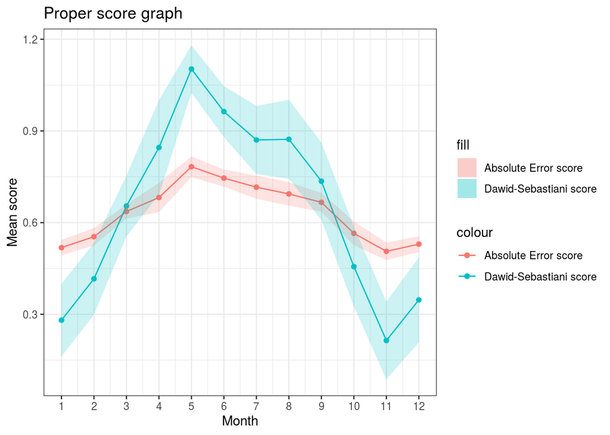

```r
score_summary_confint <- readRDS(file = "data/score_summary_confint.rds")
score_summary_confint %>%
  ggplot() +
  geom_point(aes(Month, mean_ae, colour = "Absolute Error score")) +
  geom_point(aes(Month, mean_ds, colour = "Dawid-Sebastiani score")) +
  geom_line(aes(Month, mean_ae, colour = "Absolute Error score")) +
  geom_line(aes(Month, mean_ds, colour = "Dawid-Sebastiani score")) +
  geom_ribbon(mapping = aes(x= Month, ymin = ae_lwr, ymax = ae_upr, fill = "Absolute Error score"), alpha = 0.2) +
  geom_ribbon(mapping = aes(x = Month, ymin = ds_lwr, ymax = ds_upr, fill = "Dawid-Sebastiani score"), alpha = 0.2) +
  scale_x_continuous(breaks = seq(0,12,1)) +
  ylab("Mean score") +
  ggtitle("Proper score graph")
```

We can see that the general trend for the Absolute Error score and Dawid-Sebastiani score for each of the model are the same. That is to say that the linear models estimating the `TMAX` values in the winter months (October-February) are generally better models than the summer months models. Both the Absolute Error score and Dawid-Sebastiani scores support this statement.  
The May model produces the worst scores which is highlighted by the peak in the graph. The best performing model is the November model, which is highlighted by the lowest points on the graph.  
An interesting feature of these results is that the Dawid-Sebastiani shows a more exaggerated trend when looking at the monthly model against scores compared to the Absolute Error score. An explanation for this is that the calculation of the Absolute Error score is:

$$S_{AE}(F,y) = |y- \widehat{y}_F|$$
where, $y$ is the true value and $\widehat{y}_F$ is a point estimate under $F$, the predictive median. This means when calculating the absolute error score only considers the error, which is the difference between the predicted value and the true value.
In contrast, the calculation of Dawid-Sebastiani score is given by:

$$S_{DS}(F,y) = \frac{(y- \mu_F)^2}{\sigma^2_F} + log(\sigma^2_F)$$
where $\mu_F$ is the predictive mean and $\sigma^2_F$ is the predictive variance under $F$. This means that the score also depends on the predictive variance which the the Absolute Error score did not include. We can see from the formula above that a larger predictive variance, $\sigma^2_F$, will decrease the first term but increase second term of the Dawid-Sebastiani score. Considering we will generally be dealing with standard deviations less than 1, then we will also be dealing with variance less than 1. As a result, as variance increases the first term will decrease and the second term will increase, however the second term will always be negative due to taking the $log$ of the variance.
Consequently, we see a lower and better Dawid-Sebastiani scores when the predictive variance is lower, like in the November model. On the other hand, we see larger and worse Dawid-Sebastiani scores when the predictive variance is higher. For example, the May model has a standard deviation and variance larger than 1, which makes the $log$ term positive. This is why the trend of the scores are similar between the Absolute Error score and Dawid-Sebastiani score, however the latter has a penalty for large variance in predictions.

# 4 Code appendix

## 4.1 Function definitions

```r
# Peter Ly (s1325633, peter-lyy)

# Place your function definitions that may be needed in my_code.R and report.Rmd
# in this file, including documentation.
# You can also include any needed library() calls here

suppressPackageStartupMessages(library(tidyverse))
suppressPackageStartupMessages(library(StatCompLab))

## Monthly Trends
#' Trend estimation function
#'
#' Estimates the trend by modeling the average TMIN of the month against the
#' covariate year for a weather station ID.
#'
#' @param id The identification number of the weather station to be modelled for
#' @param mon The month which the model should estimate the trend for
#' @param data The data frame which is being used that contains the required
#'   data in order to estimate the trend.
#'
#' @return A single row with 6 columns. The output is the ID, Month, trend,
#'   standard deviation of the trend, the lower and upper 95% confidence interval
#'   of the trend, using the t-distribution.

trend <- function(id, mon, data){
  trend_est<-NULL
  ID <- id
  Month <- mon
  fit <- lm(TMINBAR ~ 1 + Year, data = data %>%
              filter(Month == mon, ID == id))
  trend <- coef(fit)["Year"]
  sd <- sqrt(vcov(fit)["Year", "Year"])
  CI <-t(confint(fit)[2,])
  result <- cbind.data.frame(ID, Month, trend, sd, CI)
  row.names(result) <- NULL
  trend_est<- rbind.data.frame(trend_est, result)
  colnames(trend_est)[5] <- "lwr"
  colnames(trend_est)[6] <- "upr"
  as.data.frame(trend_est)
}

#' Monthly prediction function over years for TMINBAR
#'
#' Estimates the trend by modeling the average TMIN of the month against the
#' covariate year for a weather station ID and uses the model to predict the
#' observed values.
#'
#' @param id The identification number of the weather station to be modelled for
#' @param mon The month which the model should estimate the trend for
#' @param data The data frame which is being used that contains the required
#'   data in order to estimate the trend.
#'
#' @return Estimates a linear model for a the average TMIN month value and
#'   weather station. Using the linear model, it will predict the observed
#'   values in the data and its 95% prediciton interval.

Month_pred <- function(mon, id, data){
  Mon_pred <-NULL
  ID <- id
  Month <- mon
  Mon_fit <-lm(TMINBAR ~ 1 + Year, data = data %>%
                 filter(Month == mon, ID == id))
  newdata <- data.frame(Year = 1960:2018)
  Mon_pred <- rbind(Mon_pred, cbind(ID, Month,newdata,
                                    data.frame(pred = predict(Mon_fit,
                                                              newdata = newdata,
                                                              interval = "prediction"))))
}

## Seasonally varying variability
#' Generator for random test statics for one station
#'
#' The function permutes the data into random months and calculates the
#' test statistic for the variance of the monthly residual against the variance
#' of the set of residuals
#'
#' @param samples Number of times to permute/randomise the data.
#' @param data The data frame which is being used that contains the required
#'   data in order to permute.
#'
#' @return The output is the 12 rows x number of samples columns.
#'   Generates test statistics for all months in a year.

Test_stat_sampling <- function(samples, data){
  H0 <- var(data$residual)
  T_Month_sample <- matrix(NA, 12, samples)
  for(i in 1:samples){
    sampling <- sample(data$Month,
                       size = nrow(data),
                       replace = FALSE)
    newdata <- data
    newdata$Month <- sampling
    for(mon in 1:12){
      var_resid_month <- var((newdata %>%
                                filter(Month == mon))$residual)
      H0 <- H0
      T_Month_sample[mon, i] <- var_resid_month - H0
    }
  }
  T_Month_sample
}

## Estimation
#' Linear model estimator for the Edinburgh:ROYAL BOTANIC GARDE
#'
#' The function estimates a 12 linear models, for each month, using all other stations
#' and year as a covariates for the TMAX.
#'
#' @param data The data frame which is being used that contains the required
#'   estimate a linear model
#'
#' @return The output is the 12 x 12 data frame.
#'   This data frame contains the estimates for each covariate and intercept
#'   for each month.

estim_model <- function(data){
  model <- NULL
  for(i in 1:12){
    Month <- i
    ID <- "UKE00105888"
    Name <- "EDINBURGH: ROYAL BOTANIC GARDE"
    est <- lm(UKE00105888 ~ 1 + UKE00105874 + UKE00105875 + UKE00105884 + UKE00105885 + UKE00105886 + UKE00105887 + UKE00105930 + Year,
              data = data %>%
                filter(Month == i))
    coeff <- t(coef(est))
    result <- cbind.data.frame(ID, Name, Month, coeff)
    model <- rbind(model, result)
  }
  model
}

#' Predicts the daily TMAX for the Edinburgh:ROYAL BOTANIC GARDE by month
#'
#' The function estimates a linear model by month and predicts the TMAX value
#' using all other stations and year as a covariates.
#'
#' @param mon The month which the function should estimate and predict TMAX
#'   values for
#' @param data The data frame which is being used that contains the required
#'   estimate a linear model
#'
#' @return The day, month and year with the observed and predicted values using
#' the estimated model.

pred_model <- function(mon, data){
  data <- data %>%
    filter(Month == mon)
  Month <- mon
  ID <- "UKE00105888"
  Name <- "EDINBURGH: ROYAL BOTANIC GARDE"
  est <- lm(UKE00105888 ~ 1 + UKE00105874 + UKE00105875 + UKE00105884 + UKE00105885 + UKE00105886 + UKE00105887 + UKE00105930 + Year,
            data = data)
  Mon_pred <- cbind.data.frame(data,
                               data.frame(pred = predict(est,
                                                         data)))
  Mon_pred <- Mon_pred %>%
    select(Year, Month, Day, DecYear, True_value = UKE00105888, pred)
  Mon_pred
}


## Assessment
#' Cross validation function
#'
#' The function is used to 10-fold cross validate the month of the model.
#' It splits the data into 10 random parts, 9 are used to train the model.
#' The other subset of data is used to validate and produce a absolute-error
#' score and Dawid-Sebastiani score.
#'
#' @param mon The month for which the model should estimate and cross validate.
#' @param data The data frame which is being used that contains the required
#'   estimate a linear model, cross validate and produce scores for.
#'
#' @return The mean and the standard deviation of the absolute error score
#'   and Dawid-Sebastiani score for the monthly models.

cross_validation <- function(mon, data){
  sampled_data <- data %>%
    filter(Month == mon)
  index <- sample(rep_len(1:10, length.out = nrow(sampled_data)))
  indexed_data <-  cbind(sampled_data, indx = index)
  score_summary <- NULL
  for(k in 1:10){
    training_data <- indexed_data %>%
      filter(!indx == k)
    valid_data <- indexed_data %>%
      filter(indx == k)
    estim <- lm(UKE00105888 ~ 1 + UKE00105874 + UKE00105875 + UKE00105884 + UKE00105885 + UKE00105886 + UKE00105887 + UKE00105930 + Year,
                data = training_data)
    pred <- cbind.data.frame(valid_data, predict(estim,
                                                 newdata = valid_data,
                                                 interval = "prediction",
                                                 se.fit = TRUE))
    pred <- pred %>%
      mutate(sd = sqrt(se.fit^2 + residual.scale^2)) %>%
      select(Year, Month, Day, True_value = UKE00105888, fit = fit.fit, lwr = fit.lwr, upr = fit.upr, sd) %>%
      mutate(
        ae = proper_score("ae", True_value, median = fit),
        ds = proper_score("ds", True_value, mean = fit, sd = sd))
    score_summary <- rbind.data.frame(score_summary,
                                      pred %>%
                                        summarise(ae = mean(ae),
                                                  ds = mean(ds)))
  }
  Month <- mon
  score_summary <- score_summary %>%
    summarise(mean_ae = mean(ae),
              sd_ae = sqrt(var(ae)/10),
              mean_ds = mean(ds),
              sd_ds = sqrt(var(ds)/10))
  score_summary <- cbind.data.frame(Month, score_summary)
  score_summary
}
```

## 4.2 Analysis code

```r
# Peter Ly (s1325633, peter-lyy)

# Load function definitions
source("my_functions.R")
suppressPackageStartupMessages(library(tidyverse))
suppressPackageStartupMessages(library(StatCompLab))

# General data
station_info <- ghcnd_stations
saveRDS(station_info, file = "data/station_info.rds")

ghcnd <- left_join(ghcnd_values, ghcnd_stations, by = "ID")
saveRDS(ghcnd, file = "data/ghcnd.rds")

## Monthly trend
# Data
seasonal_TMIN <- ghcnd %>%
  pivot_wider(names_from = Element, values_from = Value) %>%
  filter(!is.na(TMIN)) %>%
  group_by(ID, Name, Month, Year) %>%
  summarise(TMINBAR = mean(TMIN), .groups = "drop")
saveRDS(seasonal_TMIN, file = "data/seasonal_TMIN.rds")

# Monthly trend estimation ALL
trend_est <- NULL
ID_vect <- ghcnd_stations$ID
for(j in ID_vect){
  for(i in 1:12){
    trend_est <- rbind.data.frame(trend_est, trend(j, i, seasonal_TMIN))
  }
}
trend_est <- left_join(ghcnd_stations[,1:2], trend_est, by = "ID")
saveRDS(trend_est, file = "data/trend_est.rds")

#January prediction data
Jan_pred <-NULL
for(j in ID_vect){
  Jan_pred <- rbind.data.frame(Jan_pred, Month_pred(1, j, seasonal_TMIN))
}

Jan_pred <- left_join(ghcnd_stations[,1:2], Jan_pred, by = "ID")
saveRDS(Jan_pred, file = "data/Jan_pred.rds")

#October predicition data
Oct_pred <-NULL
for(j in ID_vect){
  Oct_pred <- rbind.data.frame(Oct_pred, Month_pred(10, j, seasonal_TMIN))
}

Oct_pred <- left_join(ghcnd_stations[,1:2], Oct_pred, by = "ID")
saveRDS(Oct_pred, file = "data/Oct_pred.rds")

#November predicition data
Nov_pred <-NULL
for(j in ID_vect){
  Nov_pred <- rbind.data.frame(Nov_pred, Month_pred(11, j, seasonal_TMIN))
}

Nov_pred <- left_join(ghcnd_stations[,1:2], Nov_pred, by = "ID")
saveRDS(Nov_pred, file = "data/Nov_pred.rds")

#December predicition data
Dec_pred <-NULL
for(j in ID_vect){
  Dec_pred <- rbind.data.frame(Dec_pred, Month_pred(12, j, seasonal_TMIN))
}

Dec_pred <- left_join(ghcnd_stations[,1:2], Dec_pred, by = "ID")
saveRDS(Dec_pred, file = "data/Dec_pred.rds")

## Seasonally varying variability
#Balmoral residual data
Bal_residual_data <- ghcnd %>%
  pivot_wider(names_from = Element, values_from = Value) %>%
  filter(!is.na(TMIN), ID == "UKE00105875") %>%
  group_by(ID, Name, Month, Year)%>%
  select(ID, Name, Year, Month, Day, DecYear, TMIN) %>%
  mutate(TMINBAR = mean(TMIN)) %>%
  mutate(residual = (TMIN - TMINBAR))

# Observed test statistic
H0 <- var(Bal_residual_data$residual)
T_Month <- NULL
for(mon in 1:12){
  T_Month[mon] <- var((Bal_residual_data %>%
                         filter(Month == mon))$residual)
}
T_Month <- cbind.data.frame(Month = 1:12, T_Month, H0)
T_Month <- T_Month %>%
  mutate(T_stat = T_Month - H0)
saveRDS(T_Month, file = "data/T_Month.rds")

# Permutated test statistic
Test_stats <- Test_stat_sampling(2500, Bal_residual_data)

# pvalues for randomisation test
pvalue <- NULL
for(mon in 1:12){
  pvalue[mon] <- (1- mean(T_Month[mon,4] >= Test_stats[mon,]))
}
pvalues <- cbind.data.frame(Month = 1:12, pvalue = pvalue)
saveRDS(pvalues, file = "data/pvalues.rds")

## Estimation
# Estimation Data
data_est <- ghcnd %>%
  pivot_wider(names_from = Element, values_from = Value) %>%
  group_by(ID, Month, Year) %>%
  select(ID, Year, Month, Day, DecYear, TMAX) %>%
  pivot_wider(names_from = ID, values_from = TMAX) %>%
  filter(!is.na(UKE00105874), !is.na(UKE00105875), !is.na(UKE00105884),
         !is.na(UKE00105885), !is.na(UKE00105886), !is.na(UKE00105887),
         !is.na(UKE00105888), !is.na(UKE00105930))

# Model estimation for Edinburgh weather station
Edin_model  <- estim_model(data_est)
saveRDS(Edin_model, file = "data/Edin_model.rds")

# 12 Month prediction data for Edinburgh weather station
Edin_pred <- NULL
for(mon in 1:12){
  Edin_pred <- rbind.data.frame(Edin_pred, pred_model(mon,data_est))
}
saveRDS(Edin_pred, file = "data/Edin_pred.rds")

# November prediction data for Edinburgh weather station
Edin_Nov_pred <- pred_model(11, data_est)
saveRDS(Edin_Nov_pred, file = "data/Edin_Nov_pred.rds")

# May prediction data for Edinburgh weather station
Edin_May_pred <- pred_model(5, data_est)
saveRDS(Edin_May_pred, file = "data/Edin_May_pred.rds")

## Assessment
set.seed(123)

# Proper scores for Edinburgh weather station monthly models
score_summary <- NULL
for(mon in 1:12){
  score_summary <- rbind.data.frame(score_summary, cross_validation(mon, data_est))
}
saveRDS(score_summary, file = "data/score_summary.rds")

# Proper scores plot data
score_summary_confint <-  score_summary %>%
  mutate(ae_lwr = mean_ae + sd_ae *qt(.025,df=9),
         ae_upr = mean_ae + sd_ae *qt(.975,df=9),
         ds_lwr = mean_ds + sd_ds *qt(.025,df=9),
         ds_upr = mean_ds + sd_ds *qt(.975,df=9))
saveRDS(score_summary_confint, file = "data/score_summary_confint.rds")
```